# Archvale Data Analysis

Nianyu Li

2023-06-13

# 1 Loading the data

```
## Rows: 1,657
## Columns: 4
## $ patient_id        <dbl> 2509, 2793, 3246, 3479, 4388, 5266, 5511, 8459, 1209…
## $ date_of_birth     <chr> "10-Jan-1964", "12-Dec-1995", "08-Mar-1984", "31-Jul…
## $ gender            <chr> "Female", "Female", "Male", "Female", "Female", "Fem…
## $ registration_date <chr> "18-Jul-2018", "02-Mar-2021", "11-Sep-2014", "31-Mar…
```

```
## Rows: 3,603
## Columns: 7
## $ patient_id                   <dbl> 521033, 705568, 734149, 734149, 734149, 7…
## $ date_of_birth                <chr> "01-Sep-71", "16-Jun-57", "23-Apr-68", "2…
## $ gender                       <chr> "Male", "Male", "Male", "Male", "Male", "…
## $ appointment_date             <chr> "14/11/22", "06/10/22", "01/08/22", "10/0…
## $ appointment_time             <time> 14:00:00, 11:10:00, 10:15:00, 10:00:00, …
## $ clinician                    <chr> "Advanced Nurse Practitioner", "General P…
## $ planned_appointment_duration <chr> "15", "10", "15", "10", "10", "10", "10",…
```

```
## Rows: 453
## Columns: 21
## $ patient_id <dbl> 2509, 4388, 12311, 12900, 15703, 17239, 17577, 17977, 18491…
## $ ast        <dbl> 0, 0, 0, 0, 1, 0, 0, 1, 1, 1, 1, 0, 0, 0, 0, 0, 0, 1, 0, 1,…
## $ af         <dbl> 0, 0, 0, 0, 0, 0, 0, 0, 0, 0, 0, 0, 0, 0, 0, 0, 0, 0, 0, 0,…
## $ can        <dbl> 0, 0, 0, 1, 0, 0, 0, 0, 0, 0, 0, 0, 0, 0, 0, 0, 0, 0, 0, 0,…
## $ chd        <dbl> 0, 0, 0, 1, 0, 1, 0, 0, 0, 0, 0, 0, 0, 0, 0, 0, 0, 0, 0, 0,…
## $ ckd        <dbl> 0, 1, 0, 1, 0, 0, 0, 0, 0, 0, 0, 0, 0, 0, 1, 0, 0, 0, 0, 0,…
## $ cop        <dbl> 0, 1, 0, 0, 1, 1, 0, 0, 1, 0, 0, 0, 0, 0, 0, 0, 0, 0, 0, 0,…
## $ dem        <dbl> 0, 0, 0, 0, 0, 0, 0, 0, 0, 0, 0, 0, 0, 0, 0, 0, 0, 0, 0, 0,…
## $ dep        <dbl> 0, 0, 0, 0, 0, 0, 0, 0, 0, 0, 0, 0, 0, 0, 0, 0, 0, 0, 0, 0,…
## $ dm         <dbl> 1, 1, 0, 0, 0, 0, 0, 0, 0, 0, 0, 1, 1, 1, 1, 0, 0, 0, 0, 0,…
## $ ep         <dbl> 0, 0, 0, 0, 0, 0, 0, 0, 0, 0, 0, 0, 0, 0, 0, 0, 0, 0, 0, 0,…
## $ hf         <dbl> 0, 0, 0, 0, 0, 0, 0, 0, 0, 0, 0, 0, 0, 0, 0, 0, 0, 0, 0, 0,…
## $ hyp        <dbl> 0, 1, 0, 1, 1, 0, 1, 0, 0, 0, 0, 0, 1, 0, 1, 1, 1, 0, 1, 1,…
## $ ld         <dbl> 0, 0, 1, 0, 0, 0, 0, 0, 0, 0, 0, 0, 0, 1, 0, 0, 0, 0, 0, 0,…
## $ mh         <dbl> 0, 0, 0, 1, 0, 0, 0, 0, 1, 0, 0, 0, 0, 0, 0, 0, 0, 0, 0, 0,…
## $ ndh        <dbl> 1, 0, 0, 0, 0, 0, 0, 0, 0, 0, 0, 0, 0, 0, 0, 0, 1, 0, 1, 0,…
## $ ost        <dbl> 0, 0, 0, 0, 0, 0, 0, 0, 0, 0, 0, 0, 0, 0, 0, 0, 0, 0, 0, 0,…
## $ pad        <dbl> 0, 0, 0, 1, 0, 0, 0, 0, 0, 0, 0, 0, 0, 0, 0, 0, 0, 1, 0, 0,…
## $ pc         <dbl> 0, 0, 0, 0, 0, 0, 0, 0, 0, 0, 0, 0, 0, 0, 0, 0, 0, 0, 0, 0,…
## $ ra         <dbl> 0, 0, 0, 0, 0, 0, 0, 0, 0, 0, 0, 0, 0, 0, 0, 0, 0, 1, 0, 0,…
## $ sti        <dbl> 0, 0, 0, 0, 1, 0, 0, 0, 0, 0, 0, 0, 0, 0, 0, 0, 0, 0, 0, 0,…
```

# 2 Data Preparation

## 2.1 Frequencies

Sum the number of consultations of each patients and join the table with `patient` table.

```r
#Count visit times of each patients
visit_n <-
  appointment %>%
  group_by(patient_id) %>%
  summarise(visit_n = n())

#Join the table with patients record
patients_n_visits <-
  left_join(x = patient,
            y = visit_n,
            by = "patient_id") %>%

  #change NA to 0 for the patients who have never visited GP
  mutate(visit_n = replace_na(visit_n,0)) %>%

  arrange(desc(visit_n)) %>%

  print()
```

```
## # A tibble: 1,657 × 5
##    patient_id date_of_birth gender registration_date visit_n
##         <dbl> <chr>         <chr>  <chr>               <int>
##  1     413591 31-Mar-1936   Female 31-Mar-1996            25
##  2     449175 25-Jul-1996   Female 08-Nov-1996            25
##  3     203029 18-Jul-1964   Female 28-Oct-2019            24
##  4     924706 18-Dec-1950   Female 31-Mar-1996            24
##  5     596712 12-Dec-1970   Female 06-May-1994            23
##  6     390794 11-Sep-1984   Female 31-Mar-1996            21
##  7     357148 31-Dec-1984   Female 06-Jan-2017            19
##  8     693562 29-Nov-1948   Female 15-Jan-1998            19
##  9     425567 18-Dec-1966   Male   31-Mar-1996            18
## 10     617753 17-Jul-1976   Female 02-May-2012            16
## # ℹ 1,647 more rows
```

## 2.2 Age

The age of the patient might affect their behaviour. As the time frame of the appoint record is not that long (only includes record of 2022-2023), we could assume the patient’s age is this year minus the year of their birthday, though not 100% accurate.

```r
patients_n_visits_1 <-  patients_n_visits %>%

  #convert character to date
  mutate(date_of_birth = dmy(date_of_birth)) %>%

  #calculate age
  mutate(age = year(today()) - year(date_of_birth)) %>%

  print()
```

```
## # A tibble: 1,657 × 6
##    patient_id date_of_birth gender registration_date visit_n   age
##         <dbl> <date>        <chr>  <chr>               <int> <dbl>
##  1     413591 1936-03-31    Female 31-Mar-1996            25    87
##  2     449175 1996-07-25    Female 08-Nov-1996            25    27
##  3     203029 1964-07-18    Female 28-Oct-2019            24    59
##  4     924706 1950-12-18    Female 31-Mar-1996            24    73
##  5     596712 1970-12-12    Female 06-May-1994            23    53
##  6     390794 1984-09-11    Female 31-Mar-1996            21    39
##  7     357148 1984-12-31    Female 06-Jan-2017            19    39
##  8     693562 1948-11-29    Female 15-Jan-1998            19    75
##  9     425567 1966-12-18    Male   31-Mar-1996            18    57
## 10     617753 1976-07-17    Female 02-May-2012            16    47
## # ℹ 1,647 more rows
```

```r
#Assign patients to "Early_childhood(<8) and elderly(>65)" and "Others"

#Create a new variable to label patients
patients_n_visits_1 <-patients_n_visits_1 %>%
  mutate(age_group = case_when(age %in% (8:65) ~ "Others",
                               !age %in% (8:65) ~ "Under 8 or above 65")) %>%
  print()
```

```
## # A tibble: 1,657 × 7
##    patient_id date_of_birth gender registration_date visit_n   age age_group
##         <dbl> <date>        <chr>  <chr>               <int> <dbl> <chr>
##  1     413591 1936-03-31    Female 31-Mar-1996            25    87 Under 8 or a…
##  2     449175 1996-07-25    Female 08-Nov-1996            25    27 Others
##  3     203029 1964-07-18    Female 28-Oct-2019            24    59 Others
##  4     924706 1950-12-18    Female 31-Mar-1996            24    73 Under 8 or a…
##  5     596712 1970-12-12    Female 06-May-1994            23    53 Others
##  6     390794 1984-09-11    Female 31-Mar-1996            21    39 Others
##  7     357148 1984-12-31    Female 06-Jan-2017            19    39 Others
##  8     693562 1948-11-29    Female 15-Jan-1998            19    75 Under 8 or a…
##  9     425567 1966-12-18    Male   31-Mar-1996            18    57 Others
## 10     617753 1976-07-17    Female 02-May-2012            16    47 Others
## # ℹ 1,647 more rows
```

## 2.3 Registration Cohort

Patients who registered after March 2023 might have a different behaviour due to the implementation of a marketing campign. Create a new variable to show the registration cohort of the patients: people who registered before March 2023 are classified as in the `Old` cohort, whereas after March 2023 belongs to `New` cohort.

```r
patients_n_visits_2 <-  patients_n_visits_1 %>%

  #convert character to date
  mutate(registration_date = dmy(registration_date)) %>%

  #create a new variable to show their registration cohort
  mutate(cohort = case_when(registration_date > "2023-03-01" ~ "New",
                            registration_date < "2023-03-01" ~ "Old")) %>%

  print()
```

```
## # A tibble: 1,657 × 8
##    patient_id date_of_birth gender registration_date visit_n   age age_group
##         <dbl> <date>        <chr>  <date>              <int> <dbl> <chr>
##  1     413591 1936-03-31    Female 1996-03-31             25    87 Under 8 or a…
##  2     449175 1996-07-25    Female 1996-11-08             25    27 Others
##  3     203029 1964-07-18    Female 2019-10-28             24    59 Others
##  4     924706 1950-12-18    Female 1996-03-31             24    73 Under 8 or a…
##  5     596712 1970-12-12    Female 1994-05-06             23    53 Others
##  6     390794 1984-09-11    Female 1996-03-31             21    39 Others
##  7     357148 1984-12-31    Female 2017-01-06             19    39 Others
##  8     693562 1948-11-29    Female 1998-01-15             19    75 Under 8 or a…
##  9     425567 1966-12-18    Male   1996-03-31             18    57 Others
## 10     617753 1976-07-17    Female 2012-05-02             16    47 Others
## # ℹ 1,647 more rows
## # ℹ 1 more variable: cohort <chr>
```

## 2.4 Chronic Disease

Patients with chronic diseases visits GP regularly. Create a new variable called chronic_disease to show the number of disease the patient have.

```r
#convert the data to long format
chronicDisease_1 <- chronicDisease %>%
  pivot_longer(cols = -"patient_id",
               names_to = "disease",
               values_to = "yn") %>%

  group_by(patient_id) %>%
  summarise(n_disease = sum(yn))

patients_n_visits_3 <-

  #Join the chronic disease table with patients table
  left_join(x = patients_n_visits_2,
            y = chronicDisease_1,
            by = "patient_id") %>%

  #convert NA to 0
  mutate(n_disease = replace_na(n_disease,0)) %>%

  #label patients as have(Yes) and do not have(No) chronic disease
  mutate(chronic_disease = case_when(n_disease > 0 ~ "Yes",
                                     n_disease == 0 ~ "No")) %>%

  print()
```

```
## # A tibble: 1,657 × 10
##    patient_id date_of_birth gender registration_date visit_n   age age_group
##         <dbl> <date>        <chr>  <date>              <int> <dbl> <chr>
##  1     413591 1936-03-31    Female 1996-03-31             25    87 Under 8 or a…
##  2     449175 1996-07-25    Female 1996-11-08             25    27 Others
##  3     203029 1964-07-18    Female 2019-10-28             24    59 Others
##  4     924706 1950-12-18    Female 1996-03-31             24    73 Under 8 or a…
##  5     596712 1970-12-12    Female 1994-05-06             23    53 Others
##  6     390794 1984-09-11    Female 1996-03-31             21    39 Others
##  7     357148 1984-12-31    Female 2017-01-06             19    39 Others
##  8     693562 1948-11-29    Female 1998-01-15             19    75 Under 8 or a…
##  9     425567 1966-12-18    Male   1996-03-31             18    57 Others
## 10     617753 1976-07-17    Female 2012-05-02             16    47 Others
## # ℹ 1,647 more rows
## # ℹ 3 more variables: cohort <chr>, n_disease <dbl>, chronic_disease <chr>
```

## 2.5 Average appointment time

```r
#Calculate the average appointment time for patients
app_time <- appointment %>%
  group_by(patient_id) %>%
  summarise(avg_time = mean(as.integer(planned_appointment_duration)))

#join it with the patients table
patients_n_visits_4 <- left_join(x = patients_n_visits_3,
                                 y = app_time,
                                 by = "patient_id") %>%

  #convert NA to 0
  mutate(avg_time = replace_na(avg_time,0)) %>%

  print()
```

```
## # A tibble: 1,657 × 11
##    patient_id date_of_birth gender registration_date visit_n   age age_group
##         <dbl> <date>        <chr>  <date>              <int> <dbl> <chr>
##  1     413591 1936-03-31    Female 1996-03-31             25    87 Under 8 or a…
##  2     449175 1996-07-25    Female 1996-11-08             25    27 Others
##  3     203029 1964-07-18    Female 2019-10-28             24    59 Others
##  4     924706 1950-12-18    Female 1996-03-31             24    73 Under 8 or a…
##  5     596712 1970-12-12    Female 1994-05-06             23    53 Others
##  6     390794 1984-09-11    Female 1996-03-31             21    39 Others
##  7     357148 1984-12-31    Female 2017-01-06             19    39 Others
##  8     693562 1948-11-29    Female 1998-01-15             19    75 Under 8 or a…
##  9     425567 1966-12-18    Male   1996-03-31             18    57 Others
## 10     617753 1976-07-17    Female 2012-05-02             16    47 Others
## # ℹ 1,647 more rows
## # ℹ 4 more variables: cohort <chr>, n_disease <dbl>, chronic_disease <chr>,
## #   avg_time <dbl>
```

## 2.6 Average appointment intervals

```r
app_interval <- appointment %>%

  #convert character to date
  mutate(appointment_date = dmy(appointment_date)) %>%

  #group by patients
  group_by(patient_id) %>%

  #calculate average interval
  summarise(app_interval_sum = max(appointment_date) - min(appointment_date),
            visit_n = n()) %>%

  mutate(app_interval = app_interval_sum/visit_n,
         app_interval_int = as.numeric(app_interval)) %>%

  #arrange the data
  arrange(desc(app_interval)) %>%

  select(patient_id, app_interval_int)

  #Join it with patients table and omit NAs
patients_n_visits_5 <- left_join(x = patients_n_visits_4,
                                 y = app_interval,
                                 by = "patient_id") %>%

  #convert NA to 0
  mutate(app_interval_int = replace_na(app_interval_int,0)) %>%

  print()
```

```
## # A tibble: 1,657 × 12
##    patient_id date_of_birth gender registration_date visit_n   age age_group
##         <dbl> <date>        <chr>  <date>              <int> <dbl> <chr>
##  1     413591 1936-03-31    Female 1996-03-31             25    87 Under 8 or a…
##  2     449175 1996-07-25    Female 1996-11-08             25    27 Others
##  3     203029 1964-07-18    Female 2019-10-28             24    59 Others
##  4     924706 1950-12-18    Female 1996-03-31             24    73 Under 8 or a…
##  5     596712 1970-12-12    Female 1994-05-06             23    53 Others
##  6     390794 1984-09-11    Female 1996-03-31             21    39 Others
##  7     357148 1984-12-31    Female 2017-01-06             19    39 Others
##  8     693562 1948-11-29    Female 1998-01-15             19    75 Under 8 or a…
##  9     425567 1966-12-18    Male   1996-03-31             18    57 Others
## 10     617753 1976-07-17    Female 2012-05-02             16    47 Others
## # ℹ 1,647 more rows
## # ℹ 5 more variables: cohort <chr>, n_disease <dbl>, chronic_disease <chr>,
## #   avg_time <dbl>, app_interval_int <dbl>
```

# 3 Data Analysis

We make the following assumptions to identify the inappropriate users of GP services:

1. They are frequent users of GP services.
2. They are associate with potential inappropriate usage - assumptions about inappropriate usage.

## 3.1 Identify Frequent Patients

Calculate the patient’s GP frequencies to identify the frequent patients.

```r
patients_frequency <- patients_n_visits_5 %>%

  #group the patients by their frequencies
  group_by(visit_n) %>%

  #count the total number of patients and visits in each group
  summarise(patient_n = n(),
            visit_total_n = sum(visit_n)) %>%

  #calculate the percentages
  mutate(patient_pct = round(patient_n/sum(patient_n)*100,2),
         visit_pct = round(visit_total_n/sum(visit_total_n)*100,2)) %>%

  #calculate the cumulative percentages
  arrange(desc(visit_n)) %>%
  mutate(patient_cumpct = cumsum(patient_pct),
         visit_cumpct = cumsum(visit_pct)) %>%

  print()
```

```
## # A tibble: 23 × 7
##    visit_n patient_n visit_total_n patient_pct visit_pct patient_cumpct
##      <int>     <int>         <int>       <dbl>     <dbl>          <dbl>
##  1      25         2            50        0.12      1.4            0.12
##  2      24         2            48        0.12      1.35           0.24
##  3      23         1            23        0.06      0.65           0.3
##  4      21         1            21        0.06      0.59           0.36
##  5      19         2            38        0.12      1.07           0.48
##  6      18         1            18        0.06      0.5            0.54
##  7      16         3            48        0.18      1.35           0.72
##  8      15         5            75        0.3       2.1            1.02
##  9      14         5            70        0.3       1.96           1.32
## 10      13         8           104        0.48      2.92           1.8
## # ℹ 13 more rows
## # ℹ 1 more variable: visit_cumpct <dbl>
```

```r
#save the tibble as an excel
#write.xlsx(patients_frequency, "patients_frequency.xlsx")
```

From the cumulative percentages, we can tell that patients who visit the GP more than 7 times account for only about 10% of total patients, but more than 45% of the consultations. Therefore, we name this group as `Frequent` and the other as `Non-frequent`.

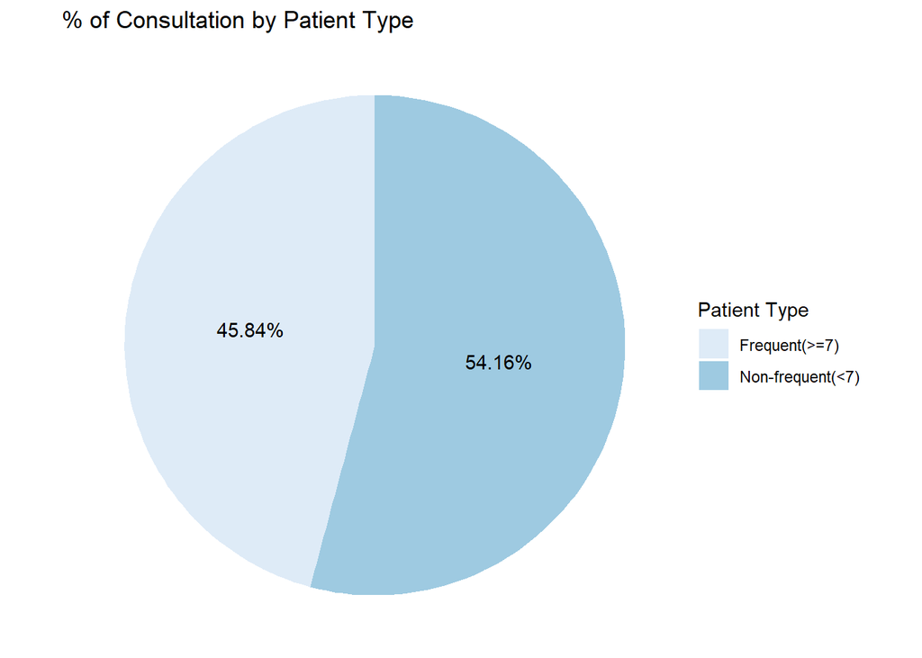

```r
patients_frequency %>%

  #summarize percentage of visits of frequent and non-frequent patients

  mutate(patient_type = case_when(visit_n >= 7 ~ "Frequent(>=7)",
                                  visit_n < 7 ~ "Non-frequent(<7)")) %>%

  group_by(patient_type) %>%

  summarise(pct_visit_total = sum(visit_pct),
            pct_patient_total = sum(patient_pct)) %>%

  ggplot()+

  aes(x = '',
      y = pct_visit_total,
      fill = patient_type) +

  geom_col(position = "stack") +

  scale_fill_brewer()+

  geom_text(aes(label = paste0(pct_visit_total,"%")),
            position = position_stack(vjust = 0.5)) +

  coord_polar("y")+

  theme_void()+

  theme(axis.ticks = element_blank(),
        axis.text = element_blank())+

  labs(title = "% of Consultation by Patient Type",
       x = NULL, y = NULL,
       fill = "Patient Type")
```

Label the patients as `Frequent` and `Non-frequent`.

```r
patients_n_visits_6 <-
  patients_n_visits_5 %>%
  mutate(segment = case_when(visit_n >= 7 ~ "Frequent",
                             visit_n < 7 ~ "Non-frequent")) %>%
  print()
```

```
## # A tibble: 1,657 × 13
##    patient_id date_of_birth gender registration_date visit_n   age age_group
##         <dbl> <date>        <chr>  <date>              <int> <dbl> <chr>
##  1     413591 1936-03-31    Female 1996-03-31             25    87 Under 8 or a…
##  2     449175 1996-07-25    Female 1996-11-08             25    27 Others
##  3     203029 1964-07-18    Female 2019-10-28             24    59 Others
##  4     924706 1950-12-18    Female 1996-03-31             24    73 Under 8 or a…
##  5     596712 1970-12-12    Female 1994-05-06             23    53 Others
##  6     390794 1984-09-11    Female 1996-03-31             21    39 Others
##  7     357148 1984-12-31    Female 2017-01-06             19    39 Others
##  8     693562 1948-11-29    Female 1998-01-15             19    75 Under 8 or a…
##  9     425567 1966-12-18    Male   1996-03-31             18    57 Others
## 10     617753 1976-07-17    Female 2012-05-02             16    47 Others
## # ℹ 1,647 more rows
## # ℹ 6 more variables: cohort <chr>, n_disease <dbl>, chronic_disease <chr>,
## #   avg_time <dbl>, app_interval_int <dbl>, segment <chr>
```

## 3.2 Hypothesis and Assumptions

Now that we have frequent users of GP, to find out inappropriate usage, we need to make a few assumptions about which group in the frequent users is more likely to use GP inappropriately. In other words, how likely is frequent usage associate with inappropriate usage for a particular group of patients.

According to the hypothesis provided, Age/Gender/Chronic Disease/Registration Cohort might have an impact on the patient’s frequency. We might take that into consideration when we decide whether the patient has an appropriate clinical need.

### 3.2.1 Age: people under 8 or above 65 are not likely to use GP inappropriately

People under 8 or above 65 account for about 1/3 of the Frequent patients, but only 1/5 of the Non-frequent patient.

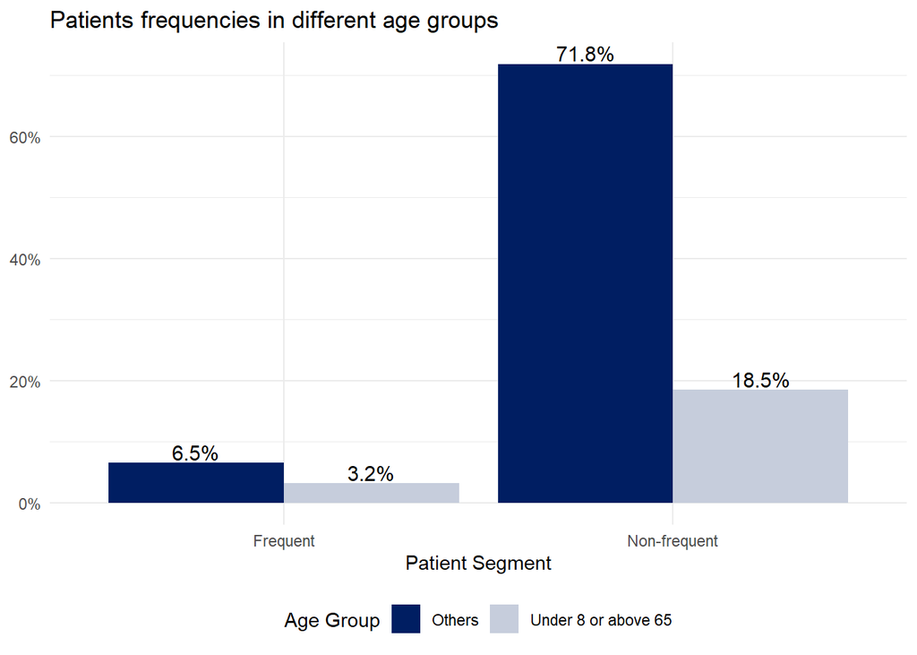

```r
patients_n_visits_6 %>%

  count(age_group = factor(age_group), segment = factor(segment)) %>%
    mutate(pct = prop.table(n)) %>%

  ggplot()+

  aes(x = segment,
      y = pct,
      fill = age_group,
      label = scales::percent(pct))+

  geom_col(position = "dodge")+

  geom_text(color = "Black",
            position = position_dodge(width = .9),
            vjust = -0.2, size = 4) +

  scale_y_continuous(labels = scales::percent)+

  scale_fill_manual(values = c("#001e62","#c6cddc"))+

  theme_minimal()+

  theme(legend.position = "bottom")+

  labs(title = "Patients frequencies in different age groups",
       x = "Patient Segment", y = NULL,
       fill = "Age Group")
```

### 3.2.2 Gender: female are not likely to use GP inappropriately

The bar plot below shows that Female accounts for more frequent patients.

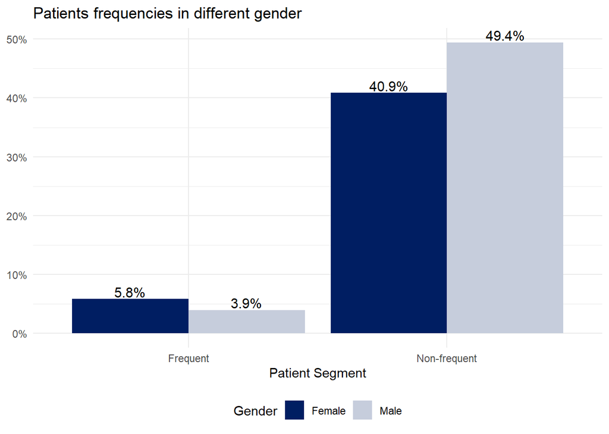

```r
patients_n_visits_6 %>%

  count(gender = factor(gender), segment = factor(segment)) %>%
    mutate(pct = prop.table(n)) %>%

  ggplot()+

  aes(x = segment,
      y = pct,
      fill = gender,
      label = scales::percent(pct))+

  geom_col(position = "dodge")+

  geom_text(color = "Black",
            position = position_dodge(width = .9),
            vjust = -0.2, size = 4) +

  scale_y_continuous(labels = scales::percent)+

  scale_fill_manual(values = c("#001e62","#c6cddc"))+

  theme_minimal()+

  theme(legend.position = "bottom")+

  labs(title = "Patients frequencies in different gender",
       x = "Patient Segment", y = NULL,
       fill = "Gender")
```

### 3.2.3 Chronic Disease: people with chronic diseases are not likely to use GP inappropriately

People with chronic diseases have a higher proportion of Frequent patients.

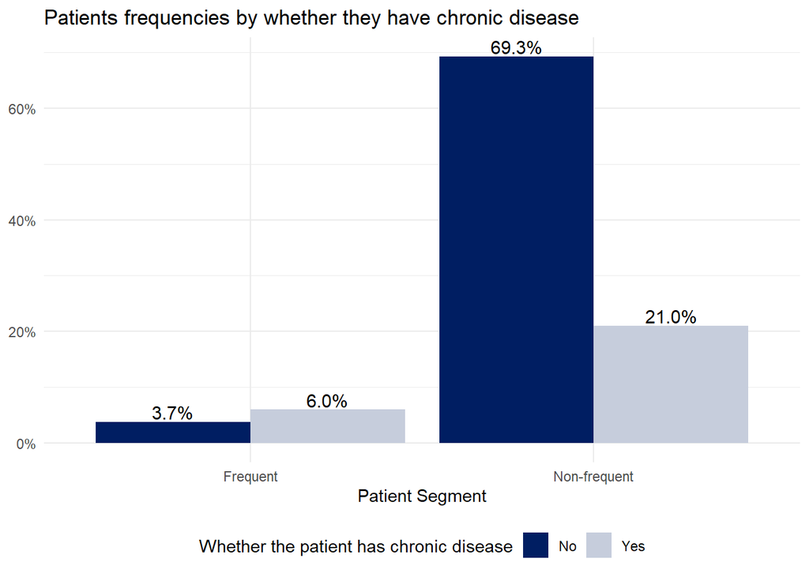

```r
patients_n_visits_6 %>%

  #first plot for patients who do/does not have chronic disease

  count(chronic_disease = factor(chronic_disease), segment = factor(segment)) %>%
    mutate(pct = prop.table(n)) %>%

  ggplot()+

  aes(x = segment,
      y = pct,
      fill = chronic_disease,
      label = scales::percent(pct))+

  geom_col(position = "dodge")+

  geom_text(color = "Black",
            position = position_dodge(width = .9),
            vjust = -0.2, size = 4)+

  scale_y_continuous(labels = scales::percent)+

  scale_fill_manual(values = c("#001e62","#c6cddc"))+

  theme_minimal()+

  theme(legend.position = "bottom")+

  labs(title = "Patients frequencies by whether they have chronic disease",
       x = "Patient Segment", y = NULL,
       fill = "Whether the patient has chronic disease")
```

The more chronic diseases the patient has, the less likely it will be a Non-frequent patient.

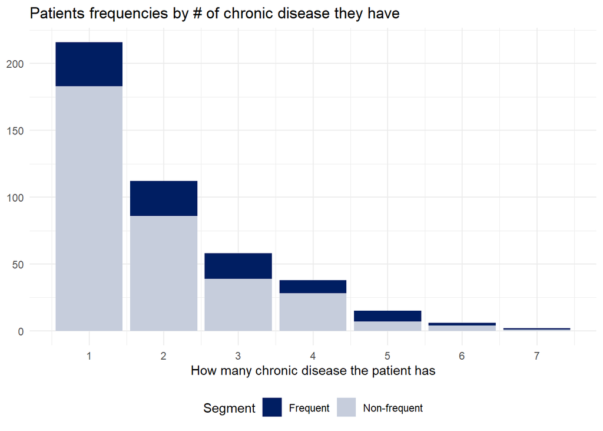

```r
patients_n_visits_6 %>%

  #then only plot for patients who have chronic disease
  filter(chronic_disease == "Yes") %>%

  ggplot()+

  aes(x = n_disease,
      fill = segment)+

  geom_bar(stat = "count")+

  scale_fill_manual(values = c("#001e62","#c6cddc"))+

  scale_x_continuous(breaks = c(1:7))+

  theme_minimal()+

  theme(legend.position = "bottom")+

  labs(title = "Patients frequencies by # of chronic disease they have",
       x = "How many chronic disease the patient has", y = NULL,
       fill = "Segment")
```

### 3.2.4 Registration Cohort: 10%-50% rule does not apply to the new cohort

```r
#Filter data for just people in the "New" cohort
patients_frequency_cohort <- patients_n_visits_6 %>%

  filter(cohort == "New") %>%

  #group the patients by their frequencies
  group_by(visit_n) %>%

  #count the total number of patients and visits in each group
  summarise(patient_n = n(),
            visit_total_n = sum(visit_n)) %>%

  #calculate the percentages
  mutate(patient_pct = round(patient_n/sum(patient_n)*100,2),
         visit_pct = round(visit_total_n/sum(visit_total_n)*100,2)) %>%

  #calculate the cumulative percentages
  arrange(desc(visit_n)) %>%
  mutate(patient_cumpct = cumsum(patient_pct),
         visit_cumpct = cumsum(visit_pct)) %>%

  print()
```

```
## # A tibble: 5 × 7
##   visit_n patient_n visit_total_n patient_pct visit_pct patient_cumpct
##     <int>     <int>         <int>       <dbl>     <dbl>          <dbl>
## 1       4         1             4        0.28     11.1            0.28
## 2       3         1             3        0.28      8.33           0.56
## 3       2         6            12        1.68     33.3            2.24
## 4       1        17            17        4.75     47.2            6.99
## 5       0       333             0       93.0       0            100.
## # ℹ 1 more variable: visit_cumpct <dbl>
```

```r
#Filter data for just people in the "Old" cohort
patients_frequency_cohort_old <- patients_n_visits_6 %>%

  filter(cohort == "Old") %>%

  #group the patients by their frequencies
  group_by(visit_n) %>%

  #count the total number of patients and visits in each group
  summarise(patient_n = n(),
            visit_total_n = sum(visit_n)) %>%

  #calculate the percentages
  mutate(patient_pct = round(patient_n/sum(patient_n)*100,2),
         visit_pct = round(visit_total_n/sum(visit_total_n)*100,2)) %>%

  #calculate the cumulative percentages
  arrange(desc(visit_n)) %>%
  mutate(patient_cumpct = cumsum(patient_pct),
         visit_cumpct = cumsum(visit_pct)) %>%

  print()
```

```
## # A tibble: 23 × 7
##    visit_n patient_n visit_total_n patient_pct visit_pct patient_cumpct
##      <int>     <int>         <int>       <dbl>     <dbl>          <dbl>
##  1      25         2            50        0.15      1.42           0.15
##  2      24         2            48        0.15      1.36           0.3
##  3      23         1            23        0.08      0.65           0.38
##  4      21         1            21        0.08      0.6            0.46
##  5      19         2            38        0.15      1.08           0.61
##  6      18         1            18        0.08      0.51           0.69
##  7      16         3            48        0.23      1.36           0.92
##  8      15         5            75        0.38      2.13           1.3
##  9      14         5            70        0.38      1.98           1.68
## 10      13         8           104        0.62      2.95           2.3
## # ℹ 13 more rows
## # ℹ 1 more variable: visit_cumpct <dbl>
```

As we can see, new cohort does not appears to behave as the 10%-50% pattern we discussed before, and 93% of the patients haven’t visited GP, therefore, we only filter for old cohort to find inappropriate usage.

### 3.2.5 Average appointment time and appointment intervals

I also assume that people with shorter average appointment time and intervals between appointments are more likely to associate with inappropriate usage.

## 3.3 Identify Inappropriate Usage

Filter for frequent patients in the old cohort.

```r
patients_oldco <- patients_n_visits_6 %>%

  #Filter only for old cohort
  filter(cohort == "Old"&
           segment == "Frequent") %>%

  print()
```

```
## # A tibble: 161 × 13
##    patient_id date_of_birth gender registration_date visit_n   age age_group
##         <dbl> <date>        <chr>  <date>              <int> <dbl> <chr>
##  1     413591 1936-03-31    Female 1996-03-31             25    87 Under 8 or a…
##  2     449175 1996-07-25    Female 1996-11-08             25    27 Others
##  3     203029 1964-07-18    Female 2019-10-28             24    59 Others
##  4     924706 1950-12-18    Female 1996-03-31             24    73 Under 8 or a…
##  5     596712 1970-12-12    Female 1994-05-06             23    53 Others
##  6     390794 1984-09-11    Female 1996-03-31             21    39 Others
##  7     357148 1984-12-31    Female 2017-01-06             19    39 Others
##  8     693562 1948-11-29    Female 1998-01-15             19    75 Under 8 or a…
##  9     425567 1966-12-18    Male   1996-03-31             18    57 Others
## 10     617753 1976-07-17    Female 2012-05-02             16    47 Others
## # ℹ 151 more rows
## # ℹ 6 more variables: cohort <chr>, n_disease <dbl>, chronic_disease <chr>,
## #   avg_time <dbl>, app_interval_int <dbl>, segment <chr>
```

Filter out the patients using the following features based on the assumptions we discussed above.

```
Features include:
```

- People who are not “Under 8 or above 65”;
- People who do not have chronic disease;
- Shorter average planned time;
- Shorter Intervals between appointments;

```r
# first for vulnerable patients
patients_oldco_sus <- patients_oldco %>%

  # Shorter average planned time
  filter(avg_time<median(avg_time) |
         # Shorter Intervals between appointments
         app_interval_int<median(app_interval_int)) %>%

  print()
```

```
## # A tibble: 121 × 13
##    patient_id date_of_birth gender registration_date visit_n   age age_group
##         <dbl> <date>        <chr>  <date>              <int> <dbl> <chr>
##  1     413591 1936-03-31    Female 1996-03-31             25    87 Under 8 or a…
##  2     449175 1996-07-25    Female 1996-11-08             25    27 Others
##  3     203029 1964-07-18    Female 2019-10-28             24    59 Others
##  4     924706 1950-12-18    Female 1996-03-31             24    73 Under 8 or a…
##  5     596712 1970-12-12    Female 1994-05-06             23    53 Others
##  6     390794 1984-09-11    Female 1996-03-31             21    39 Others
##  7     357148 1984-12-31    Female 2017-01-06             19    39 Others
##  8     693562 1948-11-29    Female 1998-01-15             19    75 Under 8 or a…
##  9     425567 1966-12-18    Male   1996-03-31             18    57 Others
## 10     617753 1976-07-17    Female 2012-05-02             16    47 Others
## # ℹ 111 more rows
## # ℹ 6 more variables: cohort <chr>, n_disease <dbl>, chronic_disease <chr>,
## #   avg_time <dbl>, app_interval_int <dbl>, segment <chr>
```

```r
patients_oldco_sus_notvul <- patients_oldco_sus %>%
  filter(age_group == "Others" &
         chronic_disease == "No") %>%
  print()
```

```
## # A tibble: 45 × 13
##    patient_id date_of_birth gender registration_date visit_n   age age_group
##         <dbl> <date>        <chr>  <date>              <int> <dbl> <chr>
##  1     449175 1996-07-25    Female 1996-11-08             25    27 Others
##  2     390794 1984-09-11    Female 1996-03-31             21    39 Others
##  3     357148 1984-12-31    Female 2017-01-06             19    39 Others
##  4     425567 1966-12-18    Male   1996-03-31             18    57 Others
##  5     617753 1976-07-17    Female 2012-05-02             16    47 Others
##  6     818746 1984-10-28    Female 2021-06-02             16    39 Others
##  7     287807 1969-07-20    Female 1996-03-31             14    54 Others
##  8     925346 2005-05-06    Female 2005-07-06             14    18 Others
##  9     639942 1986-06-14    Female 2005-03-07             13    37 Others
## 10     733389 1993-02-07    Female 2022-01-25             13    30 Others
## # ℹ 35 more rows
## # ℹ 6 more variables: cohort <chr>, n_disease <dbl>, chronic_disease <chr>,
## #   avg_time <dbl>, app_interval_int <dbl>, segment <chr>
```

```r
#save the tibble as an excel
#write.xlsx(patients_oldco_sus_notvul, "final_patient_list_1.xlsx")
```

# 4 Reflections

1. Gender does affect patients’ frequency, but it was not taken into consideration when assumptions are established.
2. Assumptions are made based on hypothesis provided, plus my understanding of inappropriate behaviour. In usual practices, qualitative analysis is done in the first place to make sure that we fully understand the reasons behind inappropriate usage.
3. I filtered the data to get the final list due to time constraints. Usually, a score card is designed to assess each patients’ behaviour, to see how close each case is to our ideal profile - in this case, a potential inappropriate user. Then select the top 50 in the ranking to get the final list.